# Analisi di telemetria di F1

## Dennis Cokaj

# Introduzione

- **Perchè:** elevata densità e disponibilità di dati telemetrici ad alta frequenza.
- **Obiettivo:** valutare quanto il pilota e le sue decisioni influenzino i risultati.

# Caso studio

- **Circuito:** GP di Silverstone in Gran Bretagna.
- **Target:** confronto interno al team Mercedes tra George Russel e Kimi Antonelli.
- **Metodologia:** Analizzare la stessa monoposto per isolare la sola componente guida.

## Domande di ricerca:

*Il divario nei tempi d'arrivo rispecchiano una reale differenza nelle prestazioni di guida?*

*In quali parametri operativi emergono le principali divergenze tra i due piloti?*

# Descrizione dei dati

- **Dataset analizzato:** Telemetrie ufficiali della F1, Ricavati tramite interfaccia open source FastF1 (theOehrly su GitHub)
- **Dati:** Dati di bordo inerenti alla guida del pilota.
- **Dati non presenti:** Parametri interni riservati alle scuderie.

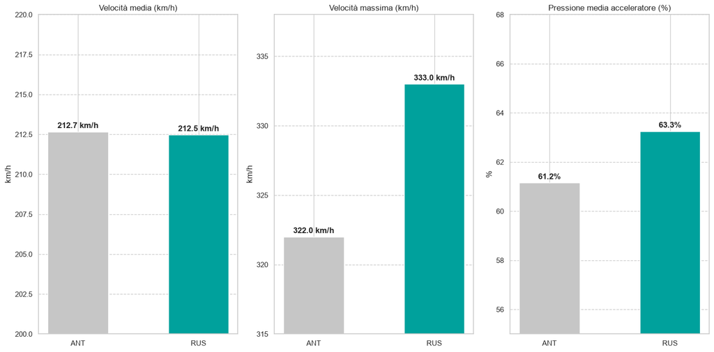

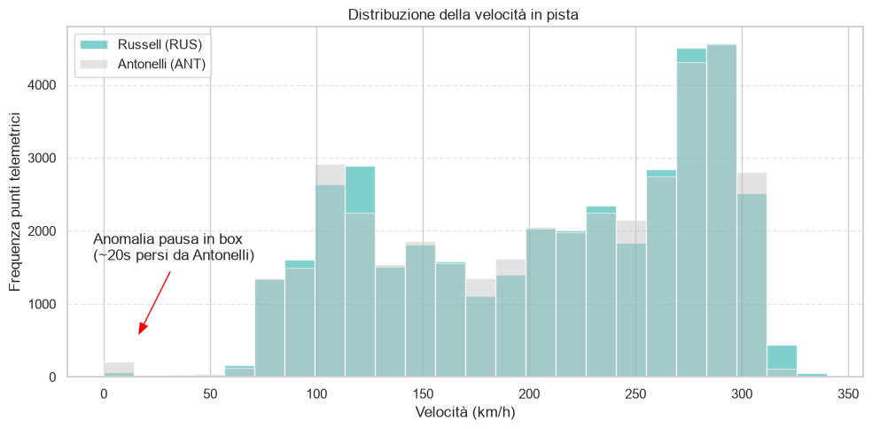

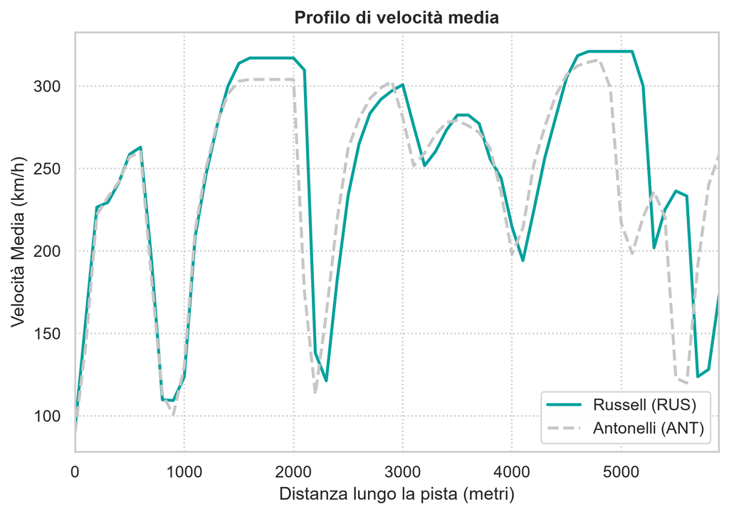

[figure not shown]

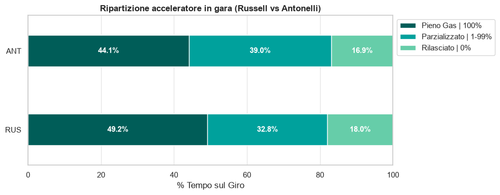

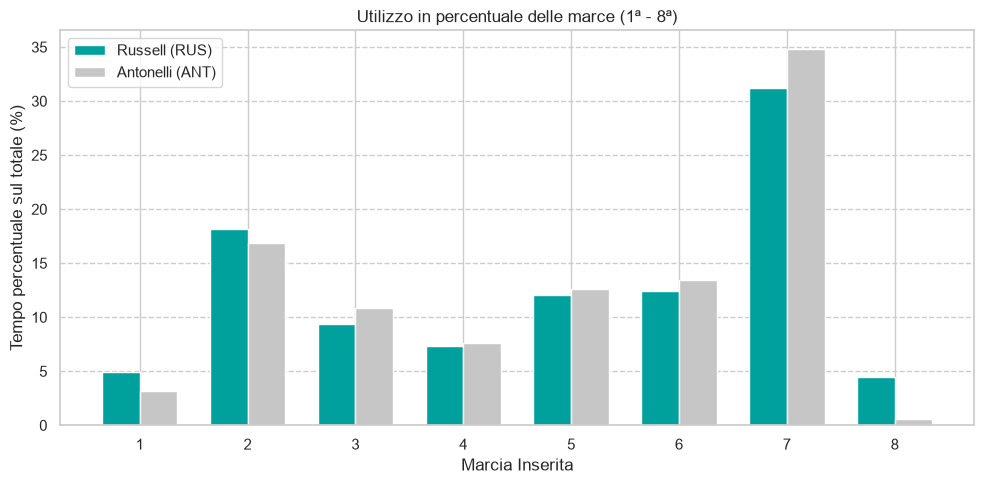

# Conclusione

- **Impatto eventi vs guida:** Il divario di tempo finale è condizionato dall'anomalia del pit-stop e non da un deficit di passo strutturale.
- **Conclusione data science:** L'analisi telemetrica dimostra come i soli dati di classifica siano fuorvianti senza una corretta fase di analisi.

Nota: mappa del tracciato di Silverstone (Layout Grand Prix 2011-presente).